# Homework 7

Xingwen Wei

### Homework questions

Please submit your homework report to Canvas as both an Rmarkdown (Rmd) file and an html file produced by it. This week, the grader will not run the Rmd file. Next week, we will learn a way to write a reproducible document including computationally intensive results.

**Question 7.1. Introduction to the greatlakes cluster.**

The greatlakes cluster is a collection of high-performance Linux machines operated by University of Michigan. Each machine has 36 CPU cores. This facilitates computationally intensive Monte Carlo statistical inference, allowing more thorough investigations than are possible on a laptop. Linux cluster computing is the standard platform for computationally intensive statistics and data science, so experience working with them is worthwhile.

Using greatlakes is optional for your STATS/DATASCI 531 final project. However, you may find that once you have run a simple parallel R command, following the instructions below, it is fairly straightforward to run the code for your project.

Read the greatlakes notes on the course website and work through the example to run the parallel foreach in the file test.R on greatlakes. If you are already familiar with greatlakes, Question 7.1 may be trivial, otherwise it is a good experience.

Have you used a Linux cluster before? Report briefly on whether you successfully ran the test code. Mention any issues that you had to overcome.

**Answer 7.1**

I have used remote Linux server before. I have successfully ran the test code on greatlakes. There was no difficulties.

**Question 7.2. Investigating the SEIR model.**

We consider an SEIR model for the Consett measles epidemic, which is the same model and data used for Homework 6. Write a report presenting the following steps. You will need to tailor the intensity of your search to the computational resources at your disposal. In particular, choose the number of starting points, number of particles employed, and the number of IF2 iterations appropriately for the size and speed of your machine. It is okay for this homework if the Monte Carlo error is larger than you would like. Optionally, you can run this on greatlakes. Whether you run it on greatlakes or a laptop or some other machine, your code should take advantage of multiple processors.

1. Conduct a local search and then a global search using the multi-stage, multi-start method.
2. How does the maximized likelihood for the SEIR model compare with what we obtained for the SIR model?
3. How do the parameter estimates differ?
4. Calculate and plot a profile likelihood over the reporting rate for the SEIR model. Construct a 95% confidence interval for the reporting rate, and discuss how this profile compares with the SIR profile in Chapter 14.

**Answer 7.2**

As before, we download the data and implement pomp in C snippets.

1. First we do a local search start with the initial parameter values, Beta=40, mu_IR=1.3, mu_EI=0.8, rho=0.5, eta=0.06, N=38000 where we fix the values of mu_IR and N as truth. We do particle filters 30 times to get an unbiased likelihood estimate of -271 with a Monte Carlo standard error of 5.4. Although we would like a smaller standard error, the additional computational cost is above the capability of this machine.

```r
registerDoRNG(123294940)
foreach(i=1:30,.combine=c) %dopar% {
  library(pomp)
  measSIR %>% pfilter(params=params,Np=50000)
} -> pf

pf %>% logLik() %>% logmeanexp(se=TRUE) -> L_pf
L_pf
```

```
##                      se
## -270.989511    5.426266
```

```r
registerDoRNG(482947940)
bake(file="local_search.rds",{
  foreach(i=1:20,.combine=c) %dopar% {
    library(pomp)
    library(tidyverse)
    measSIR %>%
      mif2(
        params=params,
        Np=2000, Nmif=50,
        cooling.fraction.50=0.5,
        rw.sd=rw.sd(Beta=0.02, rho=0.02, mu_EI=0.02, eta=ivp(0.02))
      )
  } -> mifs_local
  mifs_local
}) -> mifs_local
```

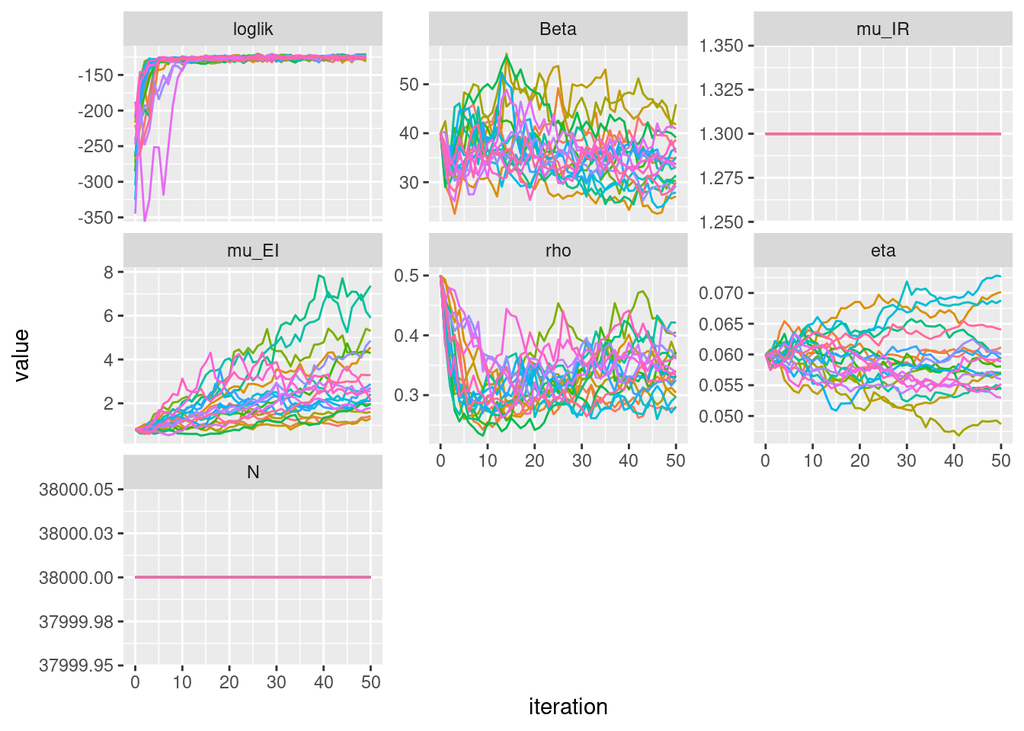

```r
mifs_local %>%
  traces() %>%
  melt() %>%
  ggplot(aes(x=iteration,y=value,group=L1,color=factor(L1)))+
  geom_line()+
  guides(color=FALSE)+
  facet_wrap(~variable,scales="free_y")
```

```r
registerDoRNG(900242057)
bake(file="lik_local.rds",{
  foreach(mf=mifs_local,.combine=rbind) %dopar% {
    library(pomp)
    library(tidyverse)
    evals <- replicate(10, logLik(pfilter(mf,Np=20000)))
    ll <- logmeanexp(evals,se=TRUE)
    mf %>% coef() %>% bind_rows() %>%
      bind_cols(loglik=ll[1],loglik.se=ll[2])
  } -> results
  results
}) -> results
```

Because of the perturbations applied to iterative filter, we use particle filter again to evaluate their likelihood for each point estimate. According to the pairwise scatter plot below, there might be a ridge in the likelihood surface of {Beta and mu_EI} and {Beta and eta}.

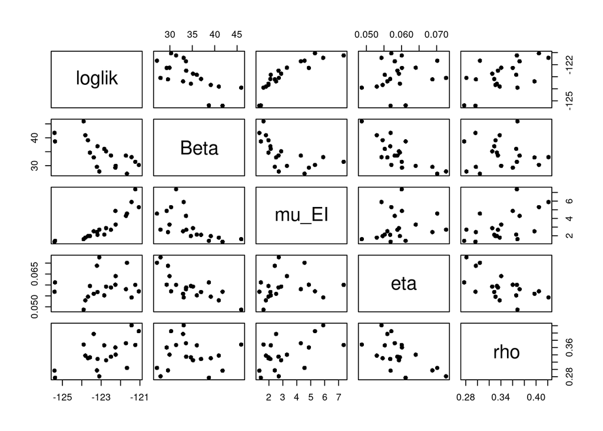

```r
pairs(~loglik+Beta+mu_EI+eta+rho,data=results,pch=16)
```

```r
set.seed(2062379496)

runif_design(
  lower=c(Beta=5,mu_EI=0, rho=0.2,eta=0),
  upper=c(Beta=80,mu_EI=5, rho=0.9,eta=0.4),
  nseq=100
) -> guesses

mf1 <- mifs_local[[1]]

bake(file="global_search.rds",{
  registerDoRNG(1270401374)
  foreach(guess=iter(guesses,"row"), .combine=rbind) %dopar% {
    library(pomp)
    library(tidyverse)
    mf1 %>%
      mif2(params=c(unlist(guess),fixed_params)) %>%
      mif2(Nmif=100) -> mf
    replicate(
      10,
      mf %>% pfilter(Np=10000) %>% logLik()
    ) %>%
      logmeanexp(se=TRUE) -> ll
    mf %>% coef() %>% bind_rows() %>%
      bind_cols(loglik=ll[1],loglik.se=ll[2])
  } -> results
  results
}) %>%
  filter(is.finite(loglik)) -> results
```

Then, we want to do a global search of the likelihood surface. We use a box that contains reasonable parameter values. $\beta \in (5, 80), \mu_{EI} \in (0, 5), \rho\in(0.2, 0.9), \eta\in(0, 0.4).$ We start with points uniformly selected from the possible box. We re-run iterative filter from the endpoints from before. After all the iterative filters for all the starting points, we use particle filter to evaluate the likelihood. We can see that the parameter values converges from uniformly distributed boxes to regions with higher likelihood. To get a closer look, we can look at each parameter’s profile likelihood.

[figure not shown]

```r
read_csv("measles_params.csv") %>%
  filter(loglik>max(loglik)-20,loglik.se<2) %>%
  sapply(range) -> box
set.seed(1196696958)
profile_design(
  eta=seq(0.01,0.85,length=30),
  lower=box[1,c("Beta","mu_EI","rho")],
  upper=box[2,c("Beta","mu_EI","rho")],
  nprof=15, type="runif"
) -> guesses

mf1 <- mifs_local[[1]]
```

```r
registerDoRNG(830007657)
bake(file="eta_profile.rds",{
  foreach(guess=iter(guesses,"row"), .combine=rbind) %dopar% {
    library(pomp)
    library(tidyverse)
    mf1 %>%
      mif2(params=c(unlist(guess),fixed_params),
           rw.sd=rw.sd(Beta=0.02,mu_EI=0.02, rho=0.02)) %>%
      mif2(Nmif=100,cooling.fraction.50=0.3) -> mf
    replicate(
      10,
      mf %>% pfilter(Np=1000) %>% logLik()) %>%
      logmeanexp(se=TRUE) -> ll
    mf %>% coef() %>% bind_rows() %>%
      bind_cols(loglik=ll[1],loglik.se=ll[2])
  } -> results
  results
}) -> results
```

```r
read_csv("measles_params.csv") %>%
  bind_rows(results) %>%
  filter(is.finite(loglik)) %>%
  arrange(-loglik) %>%
  write_csv("measles_params.csv")
read_csv("measles_params.csv") %>%
  filter(loglik>max(loglik)-10) -> all
```

We start by checking the profile likelihood at different values of eta. Because of the limitations of our computational power, we get a few values of eta from its possible range, which causes the gaps in the likelihood plot. However, we can still find the parameter values converges to regions of high likelihood.

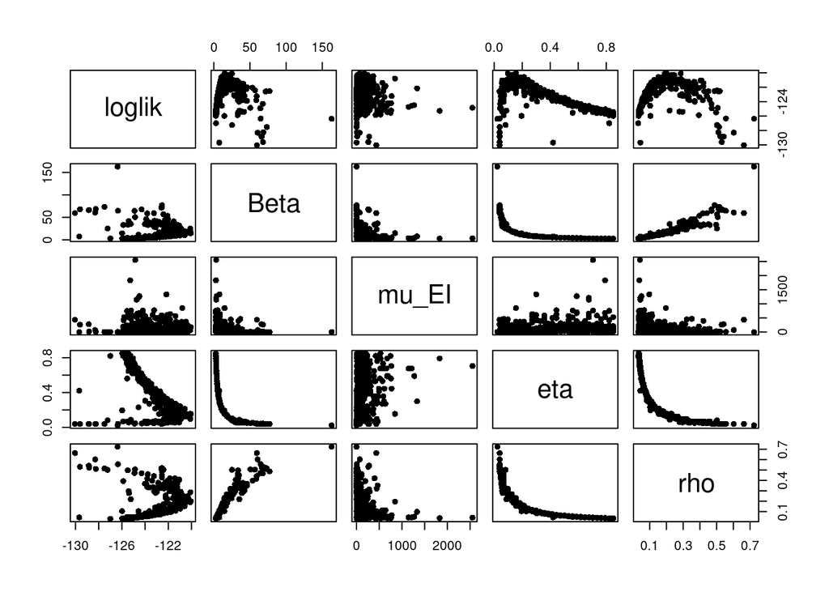

```r
pairs(~loglik+Beta+mu_EI+eta+rho,data=all,pch=16)
```

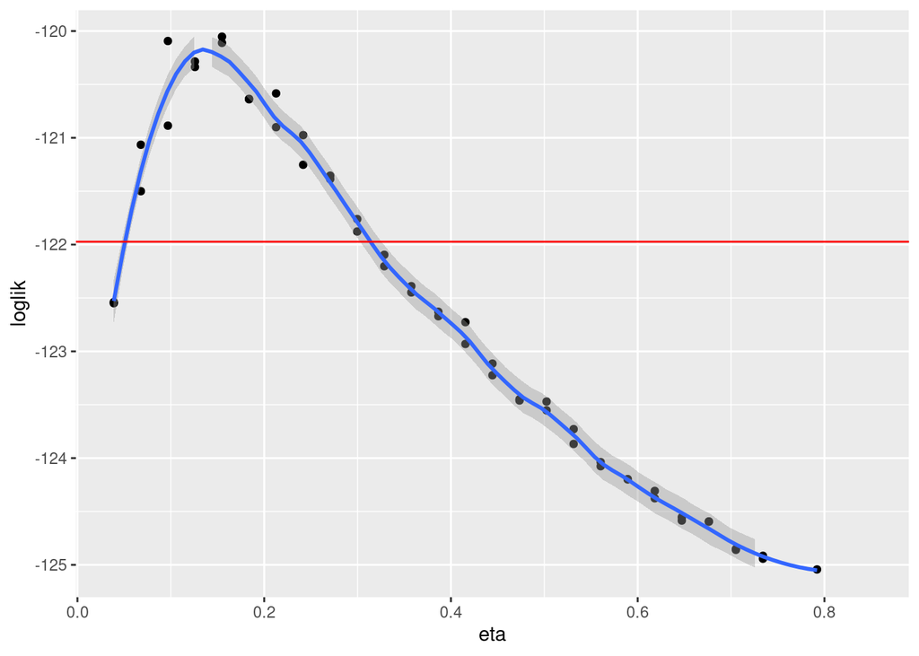

```r
maxloglik <- max(results$loglik,na.rm=TRUE)
ci.cutoff <- maxloglik-0.5*qchisq(df=1,p=0.95)

results %>%
  filter(is.finite(loglik)) %>%
  group_by(round(eta,5)) %>%
  filter(rank(-loglik)<3) %>%
  ungroup() %>%
  ggplot(aes(x=eta,y=loglik))+
  geom_point()+
  geom_smooth(method="loess",span=0.25)+
  geom_hline(color="red",yintercept=ci.cutoff)+
  lims(y=maxloglik-c(5,0))
```

```r
read_csv("measles_params.csv") %>%
  group_by(cut=round(rho,2)) %>%
  filter(rank(-loglik)<=10) %>%
  ungroup() %>%
  select(-cut,-loglik,-loglik.se) -> guesses
mf1 <- mifs_local[[1]]
registerDoRNG(2105684752)
bake(file="rho_profile.rds",{
  foreach(guess=iter(guesses,"row"), .combine=rbind) %dopar% {
    library(pomp)
    library(tidyverse)
    mf1 %>%
      mif2(params=guess,
           rw.sd=rw.sd(Beta=0.02,mu_EI=0.02, eta=ivp(0.02))) %>%
      mif2(Nmif=100,cooling.fraction.50=0.3) %>%
      mif2(Nmif=100,cooling.fraction.50=0.1) -> mf
    replicate(
      10,
      mf %>% pfilter(Np=10000) %>% logLik()) %>%
      logmeanexp(se=TRUE) -> ll
    mf %>% coef() %>% bind_rows() %>%
      bind_cols(loglik=ll[1],loglik.se=ll[2])
  } -> results
  results
}) -> results

read_csv("measles_params.csv") %>%
  bind_rows(results) %>%
  filter(is.finite(loglik)) %>%
  arrange(-loglik) %>%
  write_csv("measles_params.csv")
results %>%
  filter(is.finite(loglik)) -> results
```

Again, we can do the same for the reporting rate parameter rho. We find the parameter values converges to regions with higher likelihood.

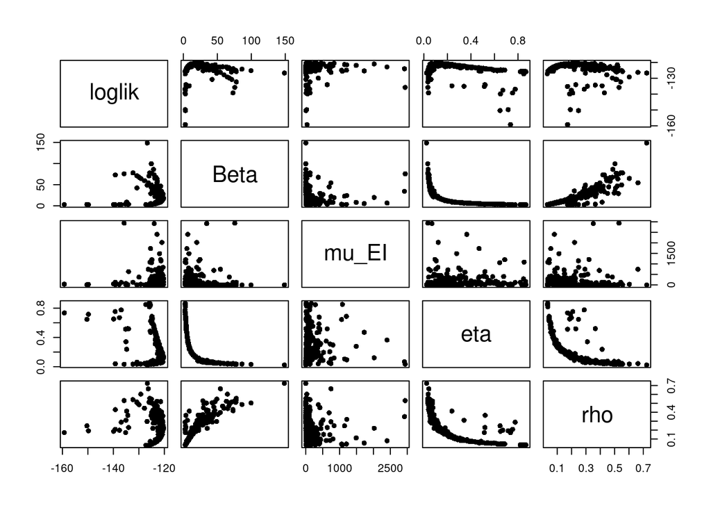

```r
pairs(~loglik+Beta+mu_EI+eta+rho,data=results,pch=16)
```

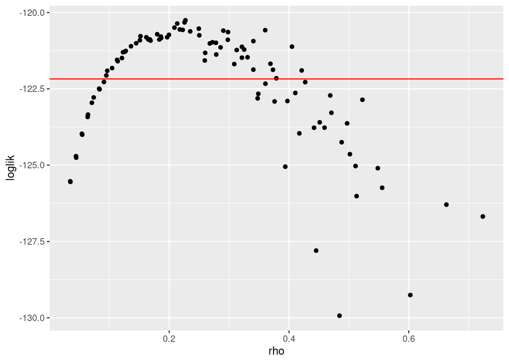

```r
results %>%
  filter(loglik>max(loglik)-10,loglik.se<1) %>%
  group_by(round(rho,2)) %>%
  filter(rank(-loglik)<3) %>%
  ungroup() %>%
  ggplot(aes(x=rho,y=loglik))+
  geom_point()+
  geom_hline(
    color="red",
    yintercept=max(results$loglik)-0.5*qchisq(df=1,p=0.95)
  )
```

**Question 7.3. This feedback response is worth credit.**

1. Explain which parts of your responses above made use of a source, meaning anything or anyone you consulted (including your class group, or other classmates, or online solutions to previous courses) to help you write or check your answers. All sources are permitted, but you are expected to explain clearly what is, and is not, your own original contribution, as discussed in the syllabus.

I used the lecture notes and the Rscript from King.

2. As for homework 6, this homework is conceptually a routine adaptation of existing code, but involves overcoming various technical hurdles. The hurdles may be overcome quite quickly, or could turn into a longer battle. Once you have finished this homework, you are in a position to carry out data analysis for a wide range of POMP models. How long did this homework take? Report on any technical difficulties that arose.

This homework takes 4 hours of human work and probably 10 hours of server time. I had a hard time to run rmd file from sbatch. It is compiled in the interactive session.

### Acknowledgements

Question 7.2 derives from material in [Simulation-based Inference for Epidemiological Dynamics](http://kingaa.github.io/sbied/index.html).